# Fitting linear mixed models in R

# Compound symmetry structure with `lme` …

Where $\sigma^2$ equals:

```r
sigma(e.lme0)^2
```

```
[1] 567.1223
```

and $\tau$ equals (coefficient(intercept)):

```r
getVarCov(e.lme0, type = "random")
```

```
Random effects variance covariance matrix
            (Intercept)
(Intercept)      1405.1
  Standard Deviations: 37.485
```

# Compound symmetry structure with `lme` …

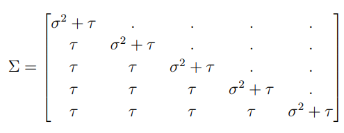

```r
getVarCov(e.lme0, type = "marginal")
```

```
id 1
Marginal variance covariance matrix
       1      2      3      4      5
1 1972.2 1405.1 1405.1 1405.1 1405.1
2 1405.1 1972.2 1405.1 1405.1 1405.1
3 1405.1 1405.1 1972.2 1405.1 1405.1
4 1405.1 1405.1 1405.1 1972.2 1405.1
5 1405.1 1405.1 1405.1 1405.1 1972.2
  Standard Deviations: 44.41 44.41 44.41 44.41 44.41
```

# Unstructed covariance matrix with `lme`

Second model can be;

$$Y_{ij} = \mu_j(X_{ij}) + u_{i1} 1_{j=1} + u_{i2} 1_{j=2} + u_{i3} 1_{j=3} + u_{i4} 1_{j=4} + u_{i5} 1_{j=5} + \varepsilon_{ij}$$

Here the vector of random effects $(u_{i1}, ... ,u_{i5})$ is independent of $\varepsilon_{ij}$ and follows a joint normal distribution centered around 0 with covariance matrix:

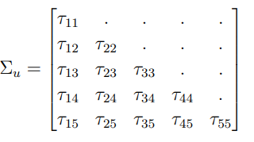

# Unstructed covariance matrix with `lme` …

We know that the observations are positively correlated so the off-diagonal coefficients should be positives. To reconstruct the matrix $\Sigma_u$ we first need to re-create the design matrix corresponding to the random effects:

```r
D <- getVarCov(e.lme, type = "random")
Z <- model.matrix(e.lme$modelStruct$reStruc,
                  data = dfL.data[dfL.data$id=="1",])
attr(Z,"ncols") <- NULL
attr(Z,"nams") <- NULL
attr(Z,"contr") <- NULL
Z
```

```
##   (Intercept) timevisit1 timevisit2 timevisit3 timevisit4
## 1           1          0          0          0          0
## 2           1          1          0          0          0
## 3           1          0          1          0          0
## 4           1          0          0          1          0
## 5           1          0          0          0          1
```

# Unstructed covariance matrix with `lme` …

we obtain $\Sigma_u$ using the matrix product:

```r
Z %*% D %*% t(Z)
```

```
##          1        2        3        4        5
## 1 2031.087 1564.247 1394.967 1454.127 1335.941
## 2 1564.247 1723.112 1396.437 1447.257 1403.249
## 3 1394.967 1396.437 1528.773 1238.197 1347.597
## 4 1454.127 1447.257 1238.197 1575.370 1270.478
## 5 1335.941 1403.249 1347.597 1270.478 2137.275
```

Recalling that we still assume that $\varepsilon_{ij} \sim N (0, \sigma^2)$ where $\sigma^2$ equals:

```r
sigma(e.lme)^2
```

```
## [1] 174.1248
```

# Unstructed covariance matrix with `lme` …

So for fixed $X$:

$$\begin{eqnarray*}
Cov[Y_{ij},Y_{ij'}] &=& Cov [\mu_j(X_{ij}) + u_{ij} + \varepsilon_{ij}, \mu_j(X_{ij'}) + u_{ij'} + \varepsilon_{ij'}] \\
&=& Cov[u_{ij}+\varepsilon_{ij},u_{ij}+\varepsilon_{ij'}] \\
&=& Cov[u_{ij},u_{ij'}] + Cov[u_{ij},\varepsilon_{ij'}] + Cov[\varepsilon_{ij},u_{ij'}] + Cov[\varepsilon_{ij},\varepsilon_{ij'}] \\
&=& \tau_{jj'} + 0 + 0 + Cov[\varepsilon_{ij},\varepsilon_{ij'}] \\
&=& \left\{
\begin{array}{ll}
\tau_{jj'} + \sigma^2 \hspace{0.5cm} if \hspace{0.5cm} j=j' \\
\tau_{jj'} \hspace{0.5cm} if \hspace{0.5cm} j \ne j'
\end{array}
\right.
\end{eqnarray*}$$

This is what we observed when using getVarCov:

```r
getVarCov(e.lme, type = "marginal")
```

```
## id 1
## Marginal variance covariance matrix
##        1      2      3      4      5
## 1 2205.2 1564.2 1395.0 1454.1 1335.9
## 2 1564.2 1897.2 1396.4 1447.3 1403.2
## 3 1395.0 1396.4 1702.9 1238.2 1347.6
## 4 1454.1 1447.3 1238.2 1749.5 1270.5
## 5 1335.9 1403.2 1347.6 1270.5 2311.4
##   Standard Deviations: 46.96 43.557 41.266 41.827 48.077
```

# `lmer` from the `lme4` package

### Compound symmetry structure

The `lmer` function works similarly to the `lme` function, except that the `random` argument is integrated into the formula, e.g. for a compound symmetry structure:

```r
library(lme4)
e.lmer <- lmer(cholesterol ~ group + time + (1 | id),
               data = dfL.data,
               na.action = na.omit)
logLik(e.lmer)
```

```
'log Lik.' -2160.3 (df=8)
```

```r
# This matches the results of lme:

e.lme <- lme(cholesterol ~ group + time, random = ~ 1 | id,
             data = dfL.data,
             na.action = na.omit)
logLik(e.lme)
```

```
'log Lik.' -2160.3 (df=8)
```

# Unstructured residual variance-covariance matrix

When estimating a mixed model with a unstructured covariance matrix, e.g.

```r
try(lmer(cholesterol ~ group + time + (time | id),
         data = dfL.data,
         na.action = na.omit))
```

```
## Error : number of observations (=447) <= number of random effects (=515) for term (time | id); the random-effects parameters and the residual variance (or scale parameter) are probably unidentifiable
```

# Unstructured residual variance-covariance matrix …

it fails when we only have one measurement per `id` and `time`. This is because the `lmer` function run automatic checks warning the user of a possible mispecification of the model. However in this example, the model is correctly specified so we have to disable the check:

```r
e.lmer <- lmer(cholesterol ~ group + time + (time | id),
               data = dfL.data,
               na.action = na.omit,
               control = lmerControl(check.nobs.vs.nRE = "ignore"))
```

```
## boundary (singular) fit: see ?isSingular
```

```r
logLik(e.lmer)
```

```
## 'log Lik.' -2147.32 (df=22)
```

# Unstructured residual variance-covariance matrix …

Even though `lmer` obtains the same log-likelihood as `lme`:

```r
e.lme <- lme(cholesterol ~ group + time,
             random =~ time | id,
             data = dfL.data,
             na.action = na.omit)
logLik(e.lme)
```

```
## 'log Lik.' -2147.318 (df=22)
```

# Unstructured residual variance-covariance matrix …

It outputs warnings that the estimation procedure did not converge properly.:

```r
eigen(e.lmer@optinfo$derivs$Hessian)$values
```

```
##  [1] 1.752210e+02 1.181608e+02 9.183982e+01 7.648746e+01 6.540299e+01
##  [6] 5.834995e+01 5.706536e+01 4.841598e+01 4.032492e+01 2.425535e+01
## [11] 1.501730e+01 1.279410e+01 6.058764e+00 3.449758e+00 8.725388e-04
```

We can see that the estimated mean parameters are slightly different from `lme`:

```r
fixef(e.lme) - fixef(e.lmer)
```

```
##   (Intercept)        groupT    timevisit1    timevisit2    timevisit3
## -1.104706e-02  1.835237e-02  3.094414e-12 -2.021504e-03 -7.332650e-05
##    timevisit4
##  1.509610e-02
```

```r
#extractSigmaLMER(e.lmer) - getVarCov(e.lme, type = "marginal")[[1]]
```

# Handling missing values in the response variable

The argument `na.action` indicates to `gls` / `lme` how to deal with missing values:

`na.action=na.fail` (default option) leads to an error in presence of missing values.

`na.action=na.omit` deals with missing values by removing the corresponding lines in the dataset.

`na.action=na.exclude` ignores the missing values. Compared to `na.omit` this means that the extractors (like fitted or residuals) will output the same number of observations compared to the original dataset.

`na.action=na.pass` will continue the execution of the function without any change. If the function cannot manage missing values, it will lead to an error.

# Inference

```r
e.gls <- gls(cholesterol ~ group + time, data = dfL.data,
             correlation = corSymm(form =~ as.numeric(time)|id),
             weights = varIdent(form =~ 1|time),
             na.action = na.omit)
logLik(e.gls)
```

```
## 'log Lik.' -2147.318 (df=21)
```

```r
#

e.lme <- lme(cholesterol ~ group + time,
             data = dfL.data,
             random =~ time | id,
             na.action = na.omit)
logLik(e.lme)
```

```
## 'log Lik.' -2147.318 (df=22)
```

# Univariate Wald tests: model parameters

To obtain p-values corresponding to testing whether a given model parameter is 0, we can call the summary function:

```r
summary(e.gls)$tTable
```

```
##                   Value Std.Error    t-value       p-value
## (Intercept) 229.7554776  6.580660 34.9137431 5.161926e-129
## groupT        0.3417066  7.773602  0.0439573  9.649583e-01
## timevisit1   14.6310680  3.075010  4.7580560  2.653301e-06
## timevisit2   18.6356975  3.388135  5.5002823  6.435671e-08
## timevisit3   26.3411440  3.436465  7.6651869  1.148153e-13
## timevisit4   25.6064658  4.830984  5.3004664  1.829287e-07
```

Confidence intervals can be obtained by calling intervals:

```r
intervals(e.gls, which = "coef")
```

```
## Approximate 95% confidence intervals
##
##  Coefficients:
##                  lower        est.     upper
## (Intercept) 216.822126 229.7554776 242.68883
## groupT      -14.936203   0.3417066  15.61962
## timevisit1    8.587574  14.6310680  20.67456
## timevisit2   11.976800  18.6356975  25.29459
## timevisit3   19.587261  26.3411440  33.09503
## timevisit4   16.111854  25.6064658  35.10108
## attr(,"label")
## [1] "Coefficients:"
```

# Univariate Wald tests: model parameters …

For `lme` models the argument `which` should be fixed to `fixed` instead:

```r
intervals(e.lme, which = "fixed")
```

```
## Approximate 95% confidence intervals
##
##  Fixed effects:
##                  lower        est.     upper
## (Intercept) 216.811486 229.7554735 242.69946
## groupT      -15.079092   0.3417134  15.76252
## timevisit1    8.582571  14.6310680  20.67956
## timevisit2   11.971388  18.6356937  25.30000
## timevisit3   19.581788  26.3411636  33.10054
## timevisit4   16.104114  25.6064782  35.10884
## attr(,"label")
## [1] "Fixed effects:"
```

# Univariate Wald tests: linear combinaison of parameters

We first need to define a contrast matrix to indicate which test we want to perform. We create the contrast matrix with as many rows as tests and as many columns as model parameters. For instance for one test:

```r
#library(multcomp)
name.coef <- names(coef(e.gls))
n.coef <- length(name.coef)
C <- matrix(0, nrow = 1, ncol = n.coef,
            dimnames = list("timevisit3-timevisit4", name.coef))
C
```

```
##                       (Intercept) groupT timevisit1 timevisit2 timevisit3
## timevisit3-timevisit4           0      0          0          0          0
##                       timevisit4
## timevisit3-timevisit4          0
```

# Univariate Wald tests: linear combinaison of parameters …

We want to test whether the change in cholesterol from baseline to visit 3 is the same as the change in cholesterol from baseline to visit 4, i.e. $\beta_{v4} − \beta_{v3} = 0$. So we fill accordingly the contrast matrix:

```r
C[1,"timevisit3"] <- -1
C[1,"timevisit4"] <- 1
C
```

```
##                       (Intercept) groupT timevisit1 timevisit2 timevisit3
## timevisit3-timevisit4           0      0          0          0         -1
##                       timevisit4
## timevisit3-timevisit4          1
```

We now call `glht`:

```r
e.glht <- glht(e.gls, linfct = C)
e.glht
```

```
##
##   General Linear Hypotheses
##
## Linear Hypotheses:
##                            Estimate
## timevisit3-timevisit4 == 0  -0.7347
```

# Univariate Wald tests: linear combinaison of parameters …

`summary` to obtain p-values:

```r
summary(e.glht)
```

```
##
##   Simultaneous Tests for General Linear Hypotheses
##
## Fit: gls(model = cholesterol ~ group + time, data = dfL.data, correlation = corSymm(form = ~as.numeric(time) |
##     id), weights = varIdent(form = ~1 | time), na.action = na.omit)
##
## Linear Hypotheses:
##                            Estimate Std. Error z value Pr(>|z|)
## timevisit3-timevisit4 == 0  -0.7347     4.6025   -0.16    0.873
## (Adjusted p values reported -- single-step method)
```

# Univariate Wald tests: linear combinaison of parameters …

`confint` to obtain confidence intervals:

```r
confint(e.glht)
```

```
##
##   Simultaneous Confidence Intervals
##
## Fit: gls(model = cholesterol ~ group + time, data = dfL.data, correlation = corSymm(form = ~as.numeric(time) |
##     id), weights = varIdent(form = ~1 | time), na.action = na.omit)
##
## Quantile = 1.96
## 95% family-wise confidence level
##
##
## Linear Hypotheses:
##                            Estimate lwr     upr
## timevisit3-timevisit4 == 0 -0.7347  -9.7554  8.2861
```

Note that by default, `summary` and `confint` used on `glht` object display p-values and confidence intervals adjusted for multiple comparisons when doing several tests (i.e. the contrast matrix contains several rows).

# Multivariate Wald test (also called F-test)

The `anova` function can be used to test whether *any* of the level of a categorical variable has an effect.

```r
anova(e.gls, type = "marginal")
```

| numDF | F-value | p-value |
| --- | --- | --- |
| 1 | 1.22e+03 | 5.16e-129 |
| 1 | 0.00193 | 0.965 |
| 4 | 16.5 | 1.34e-12 |

the line `time` corresponds to testing the null hypothesis: $\beta_{v1}=0$ or $\beta_{v2}=0$ or $\beta_{v3}=0$ or $\beta_{v4}=0$ . Note that we could also have used a contrast matrix:

```r
C <- matrix(0, nrow = 4, ncol = n.coef,
            dimnames = list(paste0("timevisit",1:4), name.coef))
C["timevisit1","timevisit1"] <- 1
C["timevisit2","timevisit2"] <- 1
C["timevisit3","timevisit3"] <- 1
C["timevisit4","timevisit4"] <- 1
C
```

```
##            (Intercept) groupT timevisit1 timevisit2 timevisit3 timevisit4
## timevisit1           0      0          1          0          0          0
## timevisit2           0      0          0          1          0          0
## timevisit3           0      0          0          0          1          0
## timevisit4           0      0          0          0          0          1
```

# Multivariate Wald test (also called F-test) …

to perform the F-test:

```r
anova(e.lme, L = C)
```

| numDF | denDF | F-value | p-value |
| --- | --- | --- | --- |
| 4 | 340 | 16.5 | 2.34e-12 |

Note that when calling anova without contrast matrix setting the argument `type` to “`marginal`” is important since otherwise `anova` outputs the result for a sequential anova.

# Inference in small samples

The p-values and confidence intervals in the previous sub-section rely on *asymptotic* results. They may not be very accurate in small samples.

Small depends both on the number of observations (n) and the number of model parameters (p): when $n−p$ is large then asymptotic results can be trusted. Otherwise resampling technics (permutations, bootstrap) are often more reliable.

`gls` and `lme` use two corrections to improve the behavior of the p-values/confidence interval in small samples:

- *REML estimation* (Restricted Maximum Likelihood) instead of *ML* estimation (Maximum Likelihood). This greatly reduce the bias of the variance estimates in small samples and is the analogue of using $\dfrac{1}{n-p}\Sigma^{n}_{i=1} \varepsilon^2_i$ instead of $\dfrac{1}{n}\Sigma^{n}_{i=1} \varepsilon^2_i$$ when estimating the variance of the residuals.
- Modeling the distribution of the model parameters using a Student’s t-distribution instead of a normal distribution. Unfortunately `gls` and `lme` use a very crude approximation of the degrees of freedom.

# Kenward Roger like approximation when using `gls`

A better approximation of the degree of freedom can be obtained using `lavaSearch2.It` has been implemented for maximum likelihood (ML) estimation and only for 2 type of covariance structure: compound symmetry and unstructured.

# Kenward Roger approximation when using `lme4`

It is to use the `lme4` package in conjunction with the `lmeTest` package to obtain appropriate inference in small sample size.